# Assignment 2: Multiple Comparisons & Permutation Tests

Behavioral Research & Statistical Methods (BRSM)

Rachakonda Hrithik Sagar (2023900021)

2026-03-15

# 1 Question 1: Bonferroni & Benjamini-Hochberg Corrections

## 1.1 Setup

```r
p <- c(0.0050, 0.0010, 0.0100, 0.0005, 0.0009, 0.0400, 0.0560, 0.0500,
       0.0480, 0.0130, 0.0370, 0.0430, 0.0020, 0.0250, 0.1100, 0.0700, 0.0800)

p_sorted   <- sort(p)
bonferroni <- p.adjust(p_sorted, method = "bonferroni")
bh         <- p.adjust(p_sorted, method = "BH")
```

## 1.2 Results Table

```r
results_q1 <- data.frame(
  Rank       = 1:length(p_sorted),
  Unadjusted = round(p_sorted, 4),
  Bonferroni = round(bonferroni, 4),
  BH         = round(bh, 4)
)
knitr::kable(results_q1, caption = "Sorted p-values with Bonferroni and BH corrections")
```

Sorted p-values with Bonferroni and BH corrections

| Rank | Unadjusted | Bonferroni | BH |
| --- | --- | --- | --- |
| 1 | 0.0005 | 0.0085 | 0.0057 |
| 2 | 0.0009 | 0.0153 | 0.0057 |
| 3 | 0.0010 | 0.0170 | 0.0057 |
| 4 | 0.0020 | 0.0340 | 0.0085 |
| 5 | 0.0050 | 0.0850 | 0.0170 |
| 6 | 0.0100 | 0.1700 | 0.0283 |
| 7 | 0.0130 | 0.2210 | 0.0316 |
| 8 | 0.0250 | 0.4250 | 0.0531 |
| 9 | 0.0370 | 0.6290 | 0.0654 |
| 10 | 0.0400 | 0.6800 | 0.0654 |
| 11 | 0.0430 | 0.7310 | 0.0654 |
| 12 | 0.0480 | 0.8160 | 0.0654 |
| 13 | 0.0500 | 0.8500 | 0.0654 |
| 14 | 0.0560 | 0.9520 | 0.0680 |
| 15 | 0.0700 | 1.0000 | 0.0793 |
| 16 | 0.0800 | 1.0000 | 0.0850 |
| 17 | 0.1100 | 1.0000 | 0.1100 |

```r
cat("Bonferroni significant (adjusted p < 0.05):", sum(bonferroni < 0.05), "\n")
```

```
## Bonferroni significant (adjusted p < 0.05): 4
```

```r
cat("BH significant (adjusted p < 0.05):",         sum(bh < 0.05), "\n")
```

```
## BH significant (adjusted p < 0.05): 7
```

## 1.3 Plot

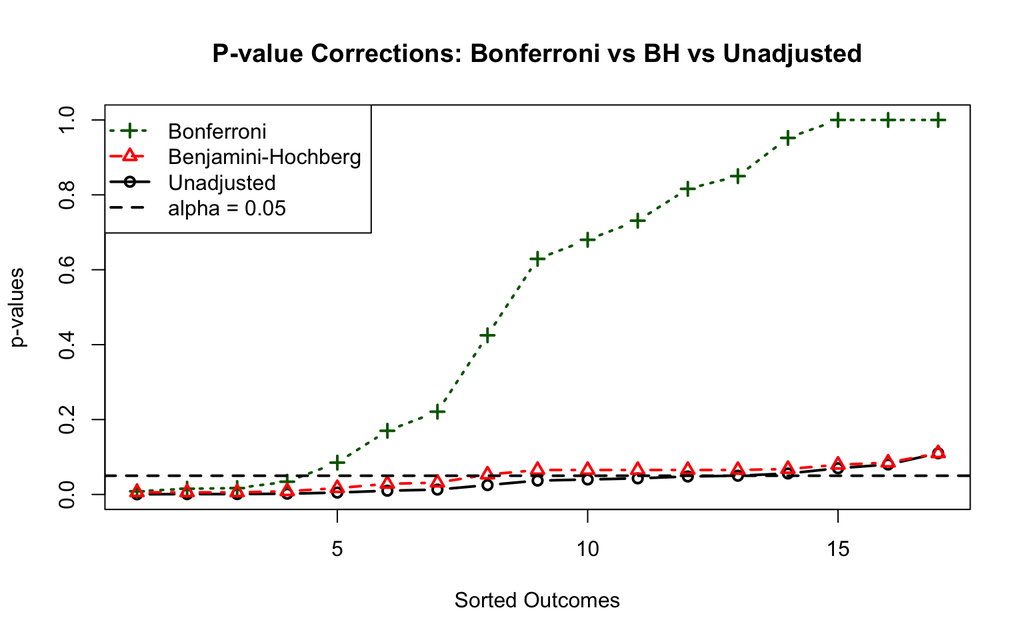

```r
plot(1:length(p_sorted), p_sorted,
     type = "b", col = "black", lwd = 2, pch = 1,
     ylim = c(0, max(bonferroni, na.rm = TRUE)),
     xlab = "Sorted Outcomes", ylab = "p-values",
     main = "P-value Corrections: Bonferroni vs BH vs Unadjusted")
lines(1:length(bonferroni), bonferroni,
      type = "b", col = "darkgreen", lwd = 2, lty = 3, pch = 3)
lines(1:length(bh), bh,
      type = "b", col = "red", lwd = 2, lty = 2, pch = 2)
abline(h = 0.05, col = "black", lwd = 2, lty = 2)
legend("topleft",
       legend = c("Bonferroni", "Benjamini-Hochberg", "Unadjusted", "alpha = 0.05"),
       col    = c("darkgreen", "red", "black", "black"),
       lty    = c(3, 2, 1, 2), pch = c(3, 2, 1, NA),
       lwd = 2, bg = "white")
```

## 1.4 Interpretation

Bonferroni correction is more conservative: it adjusts each p-value by multiplying by the total number of tests (m = 17), controlling the **family-wise error rate (FWER)**. This results in only **4 significant tests**.

Benjamini-Hochberg (BH) controls the **False Discovery Rate (FDR)** instead — a less stringent criterion that allows a small expected proportion of false discoveries among all rejected hypotheses. Accordingly, BH declares **7 tests significant**, making it the less conservative approach.

The results support the claim that Bonferroni is more conservative: the Bonferroni-adjusted p-values are substantially higher than BH-adjusted ones, and Bonferroni rejects fewer hypotheses at α = 0.05.

# 2 Question 2: Permutation Test — Mosquito Attractiveness

## 2.1 Data

The data are from Lefèvre et al. (2010), which examined whether beer consumption increases human attractiveness to mosquitoes.

- **Group 1 (Beer):** n = 25
- **Group 2 (Water):** n = 18

```r
# Read from the local CSV in the assignment folder
mosquito_file <- "assignemnt_2_data_BRSM_Results Visualization(Mosquito).csv"

if (file.exists(mosquito_file)) {
  mosq  <- read.csv(mosquito_file, fileEncoding = "UTF-8-BOM")
  mosq  <- mosq[!is.na(mosq$No_of_Mosquitoes), ]
  beer  <- mosq$No_of_Mosquitoes[mosq$Group == "Beer"]
  water <- mosq$No_of_Mosquitoes[mosq$Group == "Water"]
} else {
  # Fallback: published values from Lefevre et al. (2010)
  beer  <- c(27,19,20,20,23,17,21,24,31,26,28,20,27,19,25,31,24,28,24,29,21,21,18,27,20)
  water <- c(21,19,13,22,15,22,15,22,20,12,24,24,21,19,18,16,23,20)
}

combined <- c(beer, water)
n_beer   <- length(beer)
n_water  <- length(water)
n_total  <- length(combined)
n_iter   <- 10000

cat("Beer  group: n =", n_beer,  "| median =", median(beer),  "| mean =", round(mean(beer), 2),  "\n")
```

```
## Beer  group: n = 25 | median = 24 | mean = 23.6
```

```r
cat("Water group: n =", n_water, "| median =", median(water), "| mean =", round(mean(water), 2), "\n")
```

```
## Water group: n = 18 | median = 20 | mean = 19.22
```

## 2.2 Part (a): Difference in Medians — Directional HA

**H₀:** median(beer) ≤ median(water)  
**Hₐ (directional):** median(beer) > median(water)

```r
obs_diff_median <- median(beer) - median(water)
cat("Observed difference in medians:", obs_diff_median, "\n")
```

```
## Observed difference in medians: 4
```

```r
perm_diffs <- numeric(n_iter)
for (i in 1:n_iter) {
  shuf          <- sample(combined, n_total, replace = FALSE)
  perm_diffs[i] <- median(shuf[1:n_beer]) - median(shuf[(n_beer + 1):n_total])
}

p_val_2a <- mean(perm_diffs >= obs_diff_median)
cat("One-tailed p-value (median diff):", p_val_2a, "\n")
```

```
## One-tailed p-value (median diff): 0.0048
```

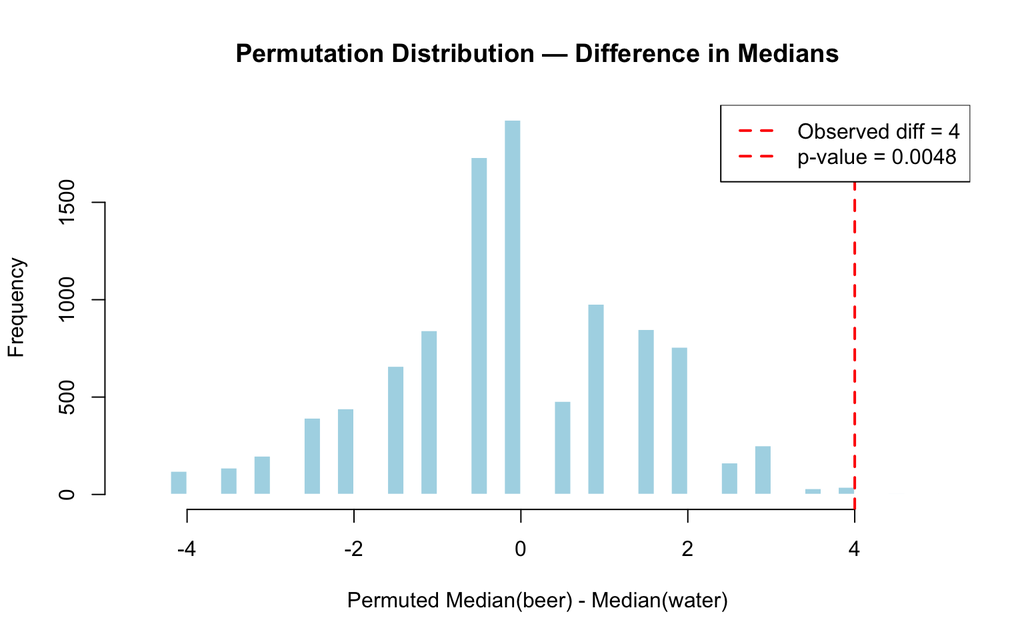

```r
hist(perm_diffs, breaks = 40, col = "lightblue", border = "white",
     main = "Permutation Distribution — Difference in Medians",
     xlab = "Permuted Median(beer) - Median(water)")
abline(v = obs_diff_median, col = "red", lwd = 2, lty = 2)
legend("topright",
       legend = c(paste("Observed diff =", obs_diff_median),
                  paste("p-value =", p_val_2a)),
       col = "red", lty = 2, lwd = 2, bg = "white")
```

**Interpretation:** The observed difference in medians is **4**. The one-tailed permutation p-value is **0.0048**, which is less than 0.05. We reject H₀ and conclude that beer consumption significantly increases mosquito attractiveness.

## 2.3 Part (b): t-Statistic — Directional HA

**H₀:** mean(beer) ≤ mean(water)  
**Hₐ (directional):** mean(beer) > mean(water)

```r
obs_t <- t.test(beer, water, var.equal = FALSE)$statistic
cat("Observed t-statistic:", round(obs_t, 4), "\n")
```

```
## Observed t-statistic: 3.6582
```

```r
perm_t <- numeric(n_iter)
for (i in 1:n_iter) {
  shuf      <- sample(combined, n_total, replace = FALSE)
  g1        <- shuf[1:n_beer]
  g2        <- shuf[(n_beer + 1):n_total]
  perm_t[i] <- t.test(g1, g2, var.equal = FALSE)$statistic
}

p_val_2b <- mean(perm_t >= obs_t)
cat("One-tailed p-value (t-stat):", p_val_2b, "\n")
```

```
## One-tailed p-value (t-stat): 6e-04
```

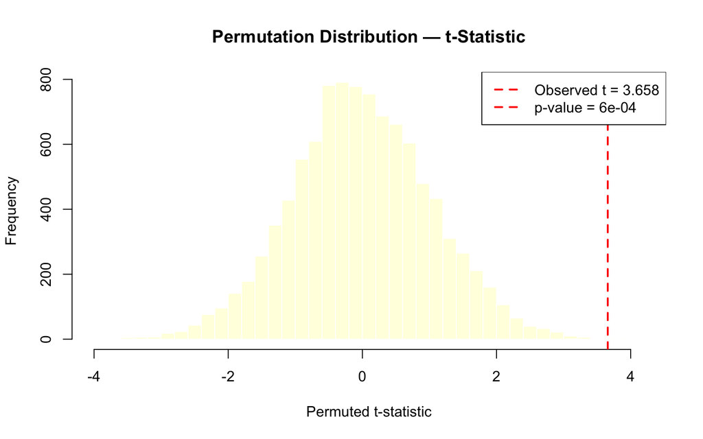

```r
hist(perm_t, breaks = 40, col = "lightyellow", border = "white",
     main = "Permutation Distribution — t-Statistic",
     xlab = "Permuted t-statistic")
abline(v = obs_t, col = "red", lwd = 2, lty = 2)
legend("topright",
       legend = c(paste("Observed t =", round(obs_t, 3)),
                  paste("p-value =", p_val_2b)),
       col = "red", lty = 2, lwd = 2, bg = "white")
```

## 2.4 Part (c): Non-directional Hₐ (Two-tailed)

**H₀:** No difference between groups  
**Hₐ (non-directional):** There is *some* difference (either direction)

```r
p_val_2a_two <- mean(abs(perm_diffs) >= abs(obs_diff_median))
p_val_2b_two <- mean(abs(perm_t)     >= abs(obs_t))

cat("Two-tailed p-value (median diff):", p_val_2a_two, "\n")
```

```
## Two-tailed p-value (median diff): 0.0169
```

```r
cat("Two-tailed p-value (t-stat):     ", p_val_2b_two, "\n")
```

```
## Two-tailed p-value (t-stat):      7e-04
```

# 3 Question 3: Permutation Test — Correlation of IQ and Test Scores

## 3.1 Load Data

```r
library(readxl)
iq_data  <- read_excel("assignment_2_IQ.xlsx")
colnames(iq_data) <- c("ID", "GPA", "IQ", "GENDER", "TESTSCORE")
iq_vals  <- iq_data$IQ
ts_vals  <- iq_data$TESTSCORE

cat("n =", nrow(iq_data), "\n")
```

```
## n = 78
```

```r
cat("IQ range:        ", range(iq_vals),  "\n")
```

```
## IQ range:         72 136
```

```r
cat("TestScore range: ", range(ts_vals), "\n")
```

```
## TestScore range:  20 80
```

## 3.2 Observed Correlation

```r
obs_cor <- cor(iq_vals, ts_vals, method = "pearson")
cat("Observed Pearson r:", round(obs_cor, 4), "\n")
```

```
## Observed Pearson r: 0.4931
```

## 3.3 Permutation Test

**H₀:** No correlation between IQ and test scores (ρ = 0)  
**Hₐ (non-directional):** There is a correlation (ρ ≠ 0)

```r
perm_cor <- numeric(n_iter)
for (i in 1:n_iter) {
  perm_cor[i] <- cor(iq_vals, sample(ts_vals), method = "pearson")
}

p_val_3 <- mean(abs(perm_cor) >= abs(obs_cor))
cat("Two-tailed permutation p-value:", p_val_3, "\n")
```

```
## Two-tailed permutation p-value: 0
```

```r
cat("Decision:", ifelse(p_val_3 < 0.05,
                        "REJECT H0 — significant correlation exists",
                        "FAIL TO REJECT H0"), "\n")
```

```
## Decision: REJECT H0 — significant correlation exists
```

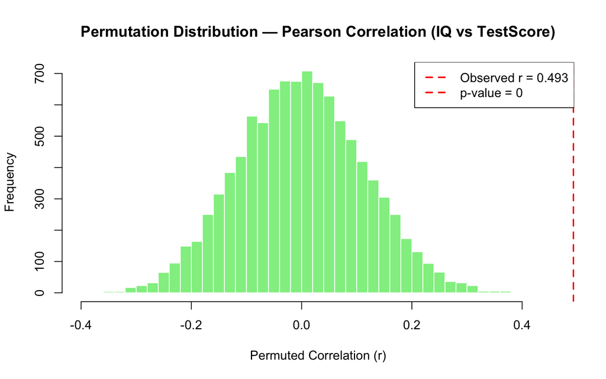

```r
hist(perm_cor, breaks = 40, col = "lightgreen", border = "white",
     main = "Permutation Distribution — Pearson Correlation (IQ vs TestScore)",
     xlab = "Permuted Correlation (r)")
abline(v =  obs_cor, col = "red", lwd = 2, lty = 2)
abline(v = -obs_cor, col = "red", lwd = 2, lty = 2)
legend("topright",
       legend = c(paste("Observed r =", round(obs_cor, 3)),
                  paste("p-value =", p_val_3)),
       col = "red", lty = 2, lwd = 2, bg = "white")
```

## 3.4 Interpretation

The observed Pearson correlation between IQ and test scores is **r = 0.4931**, indicating a moderate positive relationship. The permutation p-value is **0** — none of the 10,000 random permutations produced a correlation as extreme as the observed one.

**Conclusion:** We **reject H₀**. There is a statistically significant positive correlation between IQ and test scores (p < 0.05). Students with higher IQ scores tend to obtain higher test scores in this sample.